# Introducción a R

Crear código en R, uso colaborativo y reproducible

- Introducción
- Escribir en R
- Buenas prácticas
- Uso colaborativo

## Introducción

R es un lenguaje. De programación.

R es un lenguaje y entorno de programación especializado en análisis estadístico, visualización de datos y ciencia de datos. Utilizado por investigadores, analistas y científicos para explorar, modelar y comunicar información basada en datos de forma eficiente y reproducible.

The goal of “R for Data Science” is to help you learn the most important tools in R that will allow you to do data science.

## Objetivos:

Mejorar la comprensión y la práctica estadística.

Desarrollar habilidades en programación en R.

Aprender flujos de trabajo eficientes, limpios y reproducibles.

## What you won’t learn

1. Anállisis de la matriz de correlaciones. Deben existir altas correlaciones entre las variables.
2. Selección de los factores. El primer factor recoje la mayor proporción de variabilidad original, el segundo, la máxima no recogida pro el rpimero, etc.
3. Análisis de la matriz factorial. SE representan los factores seleccionados en forma de matriz.
4. Interpretación de los factores
5. Cálculo de las puntuaciones factoriales.

## R y Rtudio

R → Es el lenguaje de programación y el motor que realiza los cálculos estadísticos y el análisis de datos.

RStudio → Es un entorno de desarrollo integrado que facilita el uso de R con una interfaz amigable, paneles, autocompletado y herramientas visuales.

### Ejemplo del uso de R

calculadora

```r
2 + 3      # 5
```

```
[1] 5
```

```r
10 - 4     # 6
```

```
[1] 6
```

```r
3 * 5      # 15
```

```
[1] 15
```

```r
20 / 4     # 5
```

```
[1] 5
```

Acumuladora de información (objetos)

```r
x <- 10      # Asignar un valor a x
y <- 5
suma <- x + y
suma
```

```
[1] 15
```

```r
suma + 7
```

```
[1] 22
```

Uso de objetos

```r
yo_uso_la_serpiente <- 10
OtraGenteUsaElCamello <- 9
otra.gente.usa.los.puntos <- 9
Hayque_evitar.esto10 <- 2

# objetos empiezan por una letra
# son sensibles a mayusculas
```

```r
numero <- 1:10
caracter <- "del uno al diez"
numero
```

```
 [1]  1  2  3  4  5  6  7  8  9 10
```

```r
caracter
```

```
[1] "del uno al diez"
```

```r
#numero * caracter
```

## los vectores y las funciones

```r
# funcion.para.algo (arg1=col1, arg2=col2, etc)
numeros <- c(1, 2, 3, 4, 5) # Junta valores
promedio <- mean(numeros)   # Calcula la media
promedio
```

```
[1] 3
```

```r
promedio * numeros
```

```
[1]  3  6  9 12 15
```

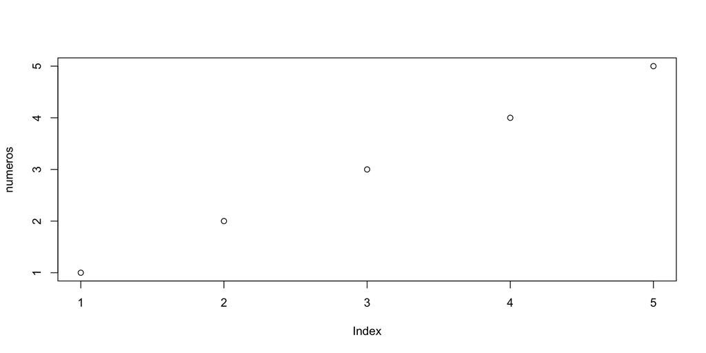

```r
plot(numeros)
```

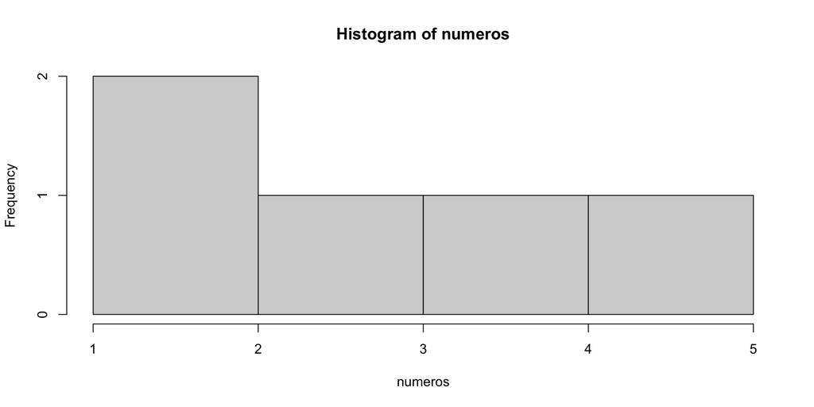

```r
hist(numeros)
```